# Loading and preprocessing the data

Load Options:

```r
suppressPackageStartupMessages(library(dplyr))
suppressPackageStartupMessages(library(data.table))
suppressPackageStartupMessages(library(ggplot2))
suppressPackageStartupMessages(library(lubridate))
```

## Loading and preprocessing the data

##### Show any code that is needed to:

- Load the data (i.e. read.csv())
- Process/transform the data (if necessary) into a format suitable for your analysis

```r
activity <- read.table(unz("activity.zip", "activity.csv"), header = T,
                       quote = "\"", sep=",", stringsAsFactors = FALSE)

## Convert the date variable from a factor to a date
activity$date <- as.Date(as.character.Date(activity$date))
activity_df <- tbl_df(activity)
activity_df <- na.omit(activity)
```

## What is mean total number of steps taken per day?

- Calcuate the total number of steps taken per day
- Make a histogram of the total number of steps taken each day

### Calcuate the total number of steps taken per day

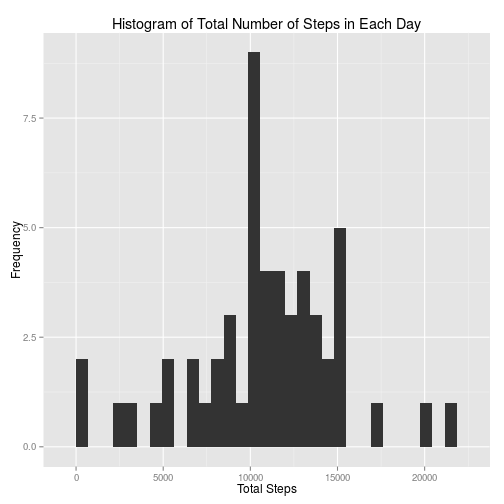

```r
total.step <- activity_df %>%
  group_by(date) %>%
  filter(!is.na(steps)) %>%
  summarise(daily.step = sum(steps, na.rm = TRUE))

## Histogram of the total number of steps taken
ggplot(total.step, aes(daily.step)) +
  geom_histogram(stat = "bin") +
  labs(x = "Total Steps", y = "Frequency",
       title="Histogram of Total Number of Steps in Each Day")
```

```r
## Calculation of mean and median of total number of steps taken per day
total.step %>%
  summarise(median = median(daily.step), mean = mean(daily.step))
```

```
## Source: local data frame [1 x 2]
##
##   median     mean
## 1  10765 10766.19
```

## What is the average daily activity pattern?

We calculate the mean number of steps for our observation period grouping by 5 minute interval.

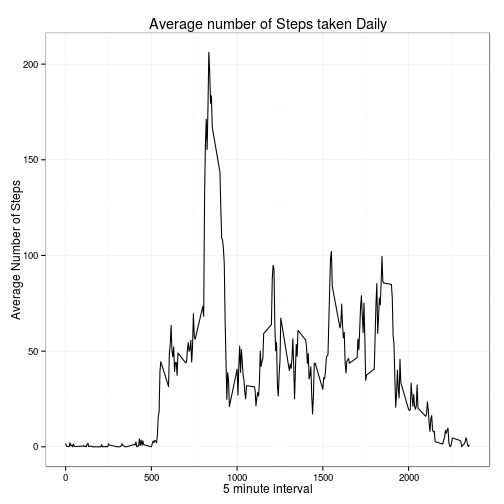

```r
interval.steps <- activity_df %>%
  group_by(interval) %>%
  summarise(steps = mean(steps, na.rm = TRUE))

ggplot(interval.steps, aes(interval, steps)) +
  geom_line() + theme_bw() +
  labs(x = "5 minute interval", y = "Average Number of Steps",
       title = "Average number of Steps taken Daily" )
```

Over our observation period we then calculate which 5 minute interval contains the maximum number of steps on average:

```r
interval.steps %>%
  arrange(desc(steps)) %>%
  slice(1)
```

```
## Source: local data frame [1 x 2]
##
##   interval    steps
## 1      835 206.1698
```

## Imputing missing values

```r
## Total number of missing values in the dataset
activity %>%
  filter(is.na(steps)) %>%
  count()
```

```
## Source: local data frame [1 x 1]
##
##      n
## 1 2304
```

To account for this we will impute by replacing missing values with the mean for each 5 minute interval:

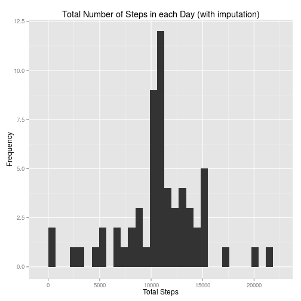

```r
imputed.activity <- tbl_df(activity) %>%
  left_join(interval.steps, by = "interval") %>%
  mutate(steps = ifelse(is.na(steps.x), steps.y, steps.x))

imputed.interval.steps <- imputed.activity %>%
  group_by(date) %>%
  summarise(steps = sum(steps))

ggplot(imputed.interval.steps, aes(steps)) +
  geom_histogram(stat = "bin") +
  labs(title = "Total Number of Steps in each Day (with imputation)",
       x = "Total Steps", y = "Frequency")
```

We now calculate the mean and median of the imputed total number of steps taken daily:

```r
## Calculation of mean and median of imputed total number of steps taken per day

imputed.interval.steps %>%
  summarise(median = median(steps), mean = mean(steps))
```

```
## Source: local data frame [1 x 2]
##
##     median     mean
## 1 10766.19 10766.19
```

## Are there differences in activity patterns between weekdays and weekends?

```r
## Factor variables into weekday and weekend.

imputed.activity.df <- tbl_df(imputed.activity) %>%
  select(date) %>%
  transmute(date = ymd(date)) %>%
  mutate(weekday = weekdays(date)) %>%
  mutate(weekday = 0 %>%
           ifelse(weekday %in% c("Saturday", "Sunday"), "Weekend", .) %>%
           ifelse(!weekday %in% c("Saturday", "Sunday"), "Weekday", .))

imputed.activity.df.merge <- tbl_df(cbind(imputed.activity.df,
                                          imputed.activity %>% select(interval, steps))) %>%
  group_by(weekday, interval) %>%
  summarise(total.steps = sum(steps, na.rm = T),
            average.steps = mean(steps, na.rm = T))
```

### Plot the two for comparison

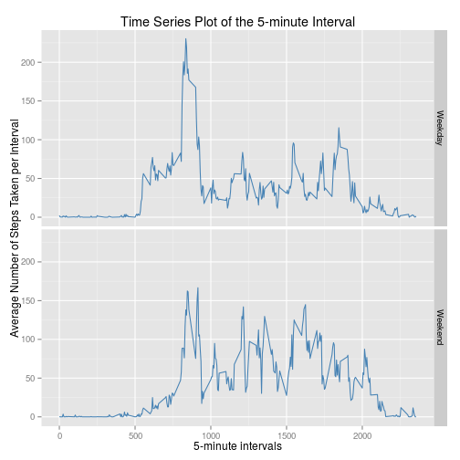

```r
ggplot(imputed.activity.df.merge, aes(interval, average.steps, color = factor(imputed.activity.df.merge$weekday))) +
  geom_line(color = "steelblue") +
  facet_grid(weekday ~ .) +
  labs(title = "Time Series Plot of the 5-minute Interval",
       x = "5-minute intervals", y = "Average Number of Steps Taken per Interval")
```

The weekend pattern is more uniform throughout while the weekday pattern has a pronounced peak and less activity through the day. This is likely due to a habitual pattern such as going to work.